# Estimating Heights of UofT Students

Jenny Oh

September 29, 2022

# Part 1

## Goal

On Reddit r/UofT, there are many posts regarding height which show high interest in height of the students at the University of Toronto. The posts usually concern whether they feel they are too short to go on a date or they feel intimidated because they think students at the University of Toronto are generally tall (hesoum, 2021; imustgrowtaller, 2022). According to Shields et al. (2011), the average height of Canadians is 175.1 cm for males and 162.3 cm for females. However, considering that there are many international students at the UofT, the Canadian height average might be a good representative of the UofT average height. Therefore, I decided to implement a survey to find out the average height of the University of Toronto students with the factors of sex, ethnicity, and countries of their origin. The goal of this survey is to find the average height of the University of Toronto students, thus students can know whether they are objectively short or not. Moreover, we can see how the factors of sex, ethnicity, and countries affect the average height. For instance, we can identify whether white UofT students are taller than Asian UofT students by conducting a hypothesis test.

## Procedure

The survey was posted in various group chats and social media from September 21 to 28, 2022. The target population of this survey is the University of Toronto students, and the frame population is the people who are in the group chats and on my social media platforms. Last, the sample population is the UofT students who submitted the survey. However there are a limited number of samples that could be collected from this method due to the short period of the survey availability and a relatively small number of students in the group chats and on social media platforms. Moreover the group chats that I am currently in are mostly statistics and computer science related and so are my friends on various social media platforms. Since students in statistics and computer science do not ideally represent the population, the data collected can be biased. Therefore, the data for calculating the average height is simulated using R. This can be a better alternative since we have data of ratios of countries that UofT students are from and the average height of various countries (University of Toronto, 2017). Moreover, the fact that the height is normally distributed and we can find the standard deviation of height of males and females (A’hearn et al., 2009, Floud, 1998) makes a simulation a better alternative.

## Showcasing the Survey

https://forms.gle/HactugP5cRtDLtJF7 (A’hearn et al., 2009)

**1. What is your biological sex at birth?**

- Male
- Female
- Other / I don’t want to answer

This question is designed based on the classification of sex by the Government of Canada (2021). It has three categories of ‘male’, ‘female’ and ‘other/ I don’t want to answer’. The question is used to identify the responder’s sex at birth since there is a major difference between males and females average height. Therefore most of the existing data of average height by country shows females and males’ height respectively (Shields et al., 2011). In addition, there could be some people who are not comfortable identifying themselves either as a male or female. For those people, they can choose the ‘other’ option. However, since there is no height data for those people who do not identify themselves as ‘other’, their responses will not be used when calculating the mean height of UofT students which could lead to a possible bias of the UofT height data.

**2. What is your height? (in cm, please just type a numeric value)** This question is included to find the mean height of UofT students in cm. The sampling procedure is anonymous, so people who are not happy with their height can feel comfortable when submitting the survey. However there is a possibility that people who are not confident with their height do not fill out the survey. We should be aware of the possible bias of people who do not feel comfortable with sharing their height. Moreover, the question indicates that the response should be in cm since it is easier to manipulate data with the same unit. People who are not familiar with the metric system can possibly be confused when submitting the survey.

- China
- India
- United States
- Korea (South)
- Hong Kong
- Taiwan
- Iran
- Turkey
- Japan
- Pakistan
- Other:

This question is asking the country that the responder’s from. If someone’s answering this question, it means that they indicate themselves as an international student. (i.e., not Canadian) The options include the categories of top 10 countries of origin of UofT international students and the ‘other’ option, so the question can be inclusive to as many students as possible (University of Toronto, 2017). However, since this question is only for international students (i.e., students who do not hold Canadian passports) the data sorts dual citizen students just as Canadians, yet does not count them as citizens of the other country. This factor can be a drawback when sorting the height of students based on their country of origin.

# Part 2

## Data

The data was simulated based one the following existing data:

1. The countries where the UofT students are from (Canada, China, India, USA, Other)
2. The ratio of ethnicity by each country
3. The average height of males and females by each country

There are 100 samples of female students and 100 samples of male students, respectively. The data has 4 variables which are i) country, ii) ethnicity, iii) sex, and iv) height. Each variable is simulated respectively and combined into one tibble.

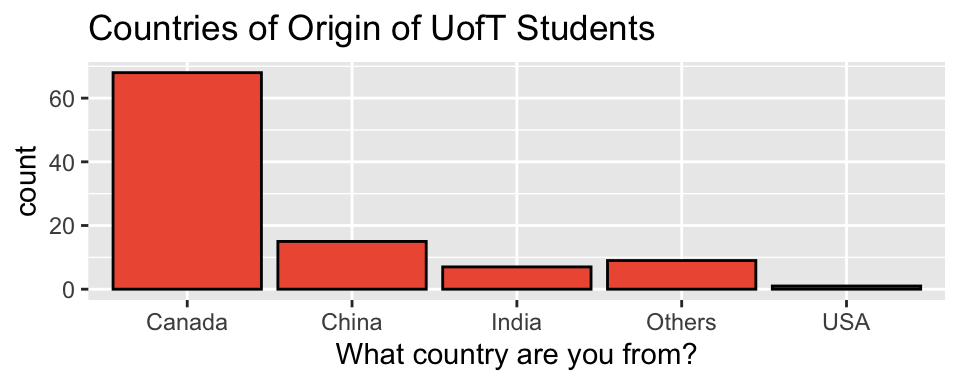

**3. Sex** : The official UofT Factbook states that the ratio of male : female is 43 : 55 (2017). It means that there are slightly more females than males at the University of Toronto. However, the UofT Factbook data covers the third sex identity, which is not applicable for the height data. Therefore for convenience of simulation we set the ratio of male : female students to 1 : 1 here. (i.e., there are 100 males and 100 females) This data is stored with a variable ‘sex’ in the simulated UofT height data.

**4. Height** : The height data is actually simulated assuming that the height data is normally distributed and the standard deviations of height are 6.35 and 5.59 for male and female students respectively (Floud, 1998). We know from existing statistics that:

1. The average height of Canadians is 175.1cm for males and 162.3cm for females (Shields et al., 2011).
2. The average height of Chinese is 172.6cm for males and 160.6cm for females (National Bureau of Statistics China, 2020).
3. The average height of Indians is 165cm for males and 152cm for females (Mamidi et al., 2011).
4. The average height of Americans is 175.3cm for males and 161.3cm for females (National Center for Health Statistics, 2021).
5. The average height of humans around the globe is 171cm for males and 159cm for females (Roser et al., 2013).

Combining all the variables mentioned above, it makes one tibble with 200 samples with variables of height, sex, country, and ethnicity. The glimpse of the UofT height data can be found in **Appendix [1]**.

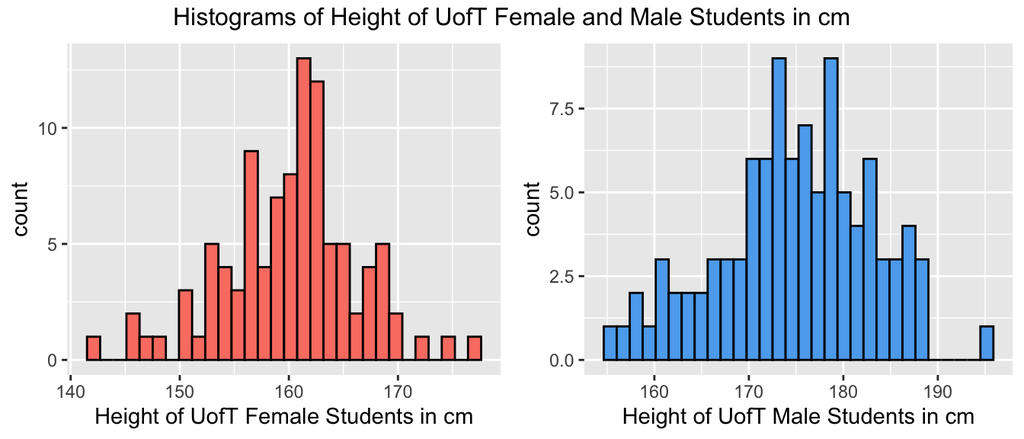

UofT Male Height by Ethnicity

| ethnicity | n | mean | sd | minimum | maximum |
| --- | --- | --- | --- | --- | --- |
| African | 2 | 168.79 | 11.02 | 161.00 | 176.59 |
| Asian | 34 | 172.07 | 8.83 | 154.97 | 186.52 |
| Indigenous | 3 | 183.59 | 4.06 | 178.98 | 186.64 |
| Latin | 1 | 172.33 | NA | 172.33 | 172.33 |
| Other | 9 | 176.42 | 4.94 | 170.06 | 184.86 |
| White | 51 | 176.28 | 7.50 | 157.68 | 194.84 |

Here are the histograms and the table generated in R with the data simulated. The gridExtra package was used to combine two plots into one grid and the knitr package was used to produce the summary table (Anderson, 2020; Xie et al., 2022).

The simulated UofT height data is clean and tidy since it has every variable needed, does not contain any N/A values, and each observation has the same unit (if numerical) without nonsensical or meaningless values.

The histograms show the height distribution of UofT male and female students respectively. From the histogram, we can see that both of male and female height distributions look symmetric and unimodal (i.e., normally distributed). Most of the female height is centred around 160 cm while most of the male height is centred around 175 cm.

The summary table shows the number of observations, mean, standard deviation, minimum and maximum of height of UofT male students grouped by ethnicity. From the table, we see that the majority of UofT male students are white and Asian. Comparing the two groups, the table shows that the mean height of UofT Asian male students is

| mean(height) |
| --- |
| 172.07 |

cm while the average white male height is

| mean(height) |
| --- |
| 176.28 |

## Methods

We will conduct a hypothesis testing to compare the height of UofT Asian and White male students and find confidence intervals of the average height of UofT male and female students respectively.

**Hypothesis Testing** I found that people posted their concerns about height on Reddit were mostly Asian male students (hesoum, 2021). Therefore, we are conducting a hypothesis test in order to test whether Asian male UofT students are genuinely shorter than White male UofT students. We assume that the data is normal and the standard deviation is equal $\sigma =6.35$ for the population, White UofT males, and Asian UofT males (Floud, 1998).

Let $\mu_{wm}$ be the mean height of white male UofT students, and $\mu_{am}$ be the mean height of Asian male UofT students.

$$H_0: \mu_{wm} = \mu_{am}$$
$$H_1: \mu_{wm} \neq \mu_{am}$$

Numerical Summary of Asian and White Males

| ethnicity | n | mean | variance |
| --- | --- | --- | --- |
| Asian | 34 | 172.07 | 77.92 |
| White | 51 | 176.28 | 56.24 |

$$P(\mid T_{df=83}\mid \geq 2.36) = 0.02$$

It is found that the p-value is 0.02.

**Confidence Interval** We found from the simulation that the average height of UofT students was 175 cm for males and 160 cm for females. However, since this is a simulated data, we cannot be certain that the population mean is the same as the simulated data. Therefore, we will derive 95% confidence intervals of the mean height of UofT students for both males and females.

Assume that the data is normally distributed and the variance is known for each female and male. Confidence interval for the unknown population mean $\mu$ where the population variance $\sigma^2$ is known:

$$(\bar{x}_{n} - z_{\alpha/2}\frac{\sigma}{\sqrt{n}}, \bar{x}_{n} + z_{\alpha/2}\frac{\sigma}{\sqrt{n}})$$

it is found that the confidence interval is (173.65, 176.14) cm for male UofT students and (159.06, 161.26) cm for female UofT students (Devore & Berk, 2012).

- **Male**:
  $$(173.65, 176.14)$$
- **Female**:
  $$(159.06 ,161.26)$$

## Results

For the hypothesis testing, it is found that the p-value is 0.02. It means that if there is no difference in height between White and Asian UofT male students, there is only a 2% chance that the height would differ by 4.22 cm in the simulated samples. The p-value of 0.02 gives us moderate evidence against the null hypothesis where there is no difference between the mean height between the two groups. Therefore, it gives some evidence that the mean height of White and Asian UofT male students differ, although we cannot be certain since the p-value is not extremely unusual. The knitr package is used to produce the summary table (Xie et al., 2022).

Summary Table of the Hypothesis Testing

| p-value | Test Statistic |
| --- | --- |
| 0.02 | t = 2.36 |

For the confidence interval, it is found that the confidence intervals are (173.6, 176.1) cm for male UofT students and (159.0, 161.3) cm for female UofT students. Therefore, we can conclude that we are 95% confident that the average height is a number between 173.6 and 176.1 cm for male UofT students and between 159.0 and 161.3 cm for female UofT students. With the confidence intervals, UofT students can see if they are fairly short or tall compared to the potential average depends on their gender among all the UofT students. The gridExtra package is used to combine two plots into one grid (Anderson, 2020).

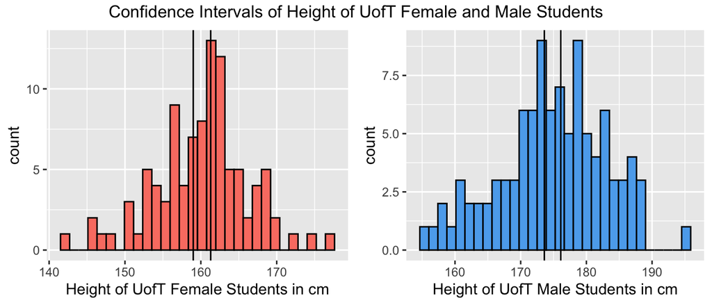

## Bibliography

1. A’hearn, B., Peracchi, F., & Vecchi, G. (2009). *Height and the Normal Distribution: Evidence from Italian Military Data.* Demography, 46(1), 1–25. https://www.ncbi.nlm.nih.gov/pmc/articles/PMC2831262/
2. Anderson, R. D. P., Sean Kross, and Brooke. (2020). *4.5 The grid Package | Mastering Software Development in R. In bookdown.org.* https://bookdown.org/rdpeng/RProgDA/the-grid-package.html
3. Bureau, U. C. (2021, August 12). *Racial and Ethnic Diversity in the United States: 2010 Census and 2020 Census.* Census.gov. https://www.census.gov/library/visualizations/interactive/racial-and-ethnic-diversity-in-the-united-states-2010-and-2020-census.html
4. Devore, J. L., & Berk, K. N. (2012). *Modern mathematical statistics with applications.* Springer, Cop.
5. Floud, R. (1998, November 1). *Height, Weight, and Body Mass of the British Population Since 1820.* National Bureau of Economic Research. https://www.nber.org/papers/h0108
6. Government of Canada, S. C. (2021, October 18). *Sex at birth of person.* Www23.Statcan.gc.ca. https://www23.statcan.gc.ca/imdb/p3Var.pl?Function=DEC&Id=24101
7. Grolemund, G. (2014, July). *Introduction to R Markdown.* Rmarkdown.rstudio.com. https://rmarkdown.rstudio.com/articles_intro.html
8. hesoum. (2021, October 1). *why do ppl here feel so tall?* Reddit. https://www.reddit.com/r/UofT/comments/pyyyjf/why_do_ppl_here_feel_so_tall/
9. imustgrowtaller. (2022, September 15). *Is my dating life doomed (5’4 guy)?* Reddit. https://www.reddit.com/r/UofT/comments/xenl42/is_my_dating_life_doomed_54_guy/
10. Mamidi, R. S., Kulkarni, B., & Singh, A. (2011). *Secular Trends in Height in Different States of India in Relation to Socioeconomic Characteristics and Dietary Intakes.* Food and Nutrition Bulletin, 32(1), 23–34. https://doi.org/10.1177/156482651103200103
11. National Bureau of Statistics China. (2020, April 8). *The Fifth National Physical Fitness Monitoring Statistical Survey System.* Www.stats.gov.cn. http://www.stats.gov.cn/tjfw/bmdcxmsp/bmzd/202004/t20200408_1737530.html
12. National Center for Health Statistics. (2021). *Vital and Health Statistics Analytical and Epidemiological Studies.* https://www.cdc.gov/nchs/data/series/sr_03/sr03-046-508.pdf
13. Roser, M., Appel, C., & Ritchie, H. (2013). *Human Height.* Our World in Data. https://ourworldindata.org/human-height
14. Shields, M., Gorber, S. C., Janssen, I., & Tremblay, M. S. (2011). *The bias in self-reported estimates of obesity in Canadian health surveys: An update on establishing correction equations for adults.* Canadian Journal of Diabetes, 35(2), 200. https://doi.org/10.1016/s1499-2671(11)52226-9
15. Statistics Canada. (2017, October 25). *Ethnic and cultural origins of Canadians: Portrait of a rich heritage.* Statcan.gc.ca; Government of Canada, Statistics Canada. https://www12.statcan.gc.ca/census-recensement/2016/as-sa/98-200-x/2016016/98-200-x2016016-eng.cfm
16. Thapar, R., & K.R. Dikshit. (2019). *India - People.* In Encyclopædia Britannica. https://www.britannica.com/place/India/People
17. The University of North Carolina. (2010). *LibGuides: Chinese Ethnic Groups: Overview Statistics.* Unc.edu. https://guides.lib.unc.edu/china_ethnic/statistics
18. University of Toronto. (2017). *Quick Facts | University of Toronto.* Utoronto.ca. https://www.utoronto.ca/about-u-of-t/quick-facts
19. Xie, Y., Dervieux, C., & Riederer, E. (2022). *10.1 The function knitr::kable() | R Markdown Cookbook. In bookdown.org.* CRC Press. https://bookdown.org/yihui/rmarkdown-cookbook/kable.html

## Appendix

### [1]

Here is a glimpse of the data set simulated:

```
## Rows: 200
## Columns: 4
## $ height    <dbl> 162.6645, 182.9874, 176.6701, 188.6707, 169.0427, 174.9084, …
## $ sex       <chr> "Male", "Male", "Male", "Male", "Male", "Male", "Male", "Mal…
## $ country   <chr> "Canada", "Canada", "Canada", "Canada", "Canada", "Canada", …
## $ ethnicity <chr> "White", "White", "White", "White", "White", "White", "White…
```

### [2]

- Pooled variance:
  $$s^2_{p} = \frac{(n_{wm}-1)s^2_{wm}+(n_{am}-1)s^2_{am}}{n_{wm}+n_{am}-2} =
  \frac{50(56.23537)+33(77.92057)}{51+34-2} = 64.85719651$$
- Test Statistic:
  $$t = \frac{(\bar{x}_{wm}-\bar{x}_{am})-(\mu_{wm}-\mu_{am})}{\sqrt{{s^2_{p}}(\frac{1}{n_{wm}}+\frac{1}{n_{am}})}}=
  \frac{(176.2847 - 172.0682)}{\sqrt{{64.85719651}(\frac{1}{51}+\frac{1}{34})}}=2.364765617$$
- Sampling Distribution: $t \sim T_{df=n_{wm}-n_{am}-2}$, which is $t \sim T_{df= 83}$
- P-value: This is a two-tailed test, find the probability of observing a difference in mean scores as extreme as was observed. In our data, $\bar{x}_{wm}-\bar{x}_{am}=4.216514$.

$$P(\mid T_{df=83}\mid \geq 2.364765617) = 0.01018758 \cdot 2 = 0.02037515$$

### [3]

Confidence interval: $(174.8928 -1.96 \cdot \frac{6.35}{\sqrt{100}}, 174.8928 +1.96 \cdot \frac{6.35}{\sqrt{100}})$